# Explore and Summarize data project with R

Hindam

January 27, 2019

This report explores a dataset containing quality and attributes for approximately 1600 red wines. ***

```
## [1] 1599   13
```

- So, Our data consists of 1599 observations and 13 variables

```
## 'data.frame':    1599 obs. of  13 variables:
##  $ X                   : int  1 2 3 4 5 6 7 8 9 10 ...
##  $ fixed.acidity       : num  7.4 7.8 7.8 11.2 7.4 7.4 7.9 7.3 7.8 7.5 ...
##  $ volatile.acidity    : num  0.7 0.88 0.76 0.28 0.7 0.66 0.6 0.65 0.58 0.5 ...
##  $ citric.acid         : num  0 0 0.04 0.56 0 0 0.06 0 0.02 0.36 ...
##  $ residual.sugar      : num  1.9 2.6 2.3 1.9 1.9 1.8 1.6 1.2 2 6.1 ...
##  $ chlorides           : num  0.076 0.098 0.092 0.075 0.076 0.075 0.069 0.065 0.073 0.071 ...
##  $ free.sulfur.dioxide : num  11 25 15 17 11 13 15 15 9 17 ...
##  $ total.sulfur.dioxide: num  34 67 54 60 34 40 59 21 18 102 ...
##  $ density             : num  0.998 0.997 0.997 0.998 0.998 ...
##  $ pH                  : num  3.51 3.2 3.26 3.16 3.51 3.51 3.3 3.39 3.36 3.35 ...
##  $ sulphates           : num  0.56 0.68 0.65 0.58 0.56 0.56 0.46 0.47 0.57 0.8 ...
##  $ alcohol             : num  9.4 9.8 9.8 9.8 9.4 9.4 9.4 10 9.5 10.5 ...
##  $ quality             : int  5 5 5 6 5 5 5 7 7 5 ...
```

```
##        X          fixed.acidity   volatile.acidity  citric.acid
##  Min.   :   1.0   Min.   : 4.60   Min.   :0.1200   Min.   :0.000
##  1st Qu.: 400.5   1st Qu.: 7.10   1st Qu.:0.3900   1st Qu.:0.090
##  Median : 800.0   Median : 7.90   Median :0.5200   Median :0.260
##  Mean   : 800.0   Mean   : 8.32   Mean   :0.5278   Mean   :0.271
##  3rd Qu.:1199.5   3rd Qu.: 9.20   3rd Qu.:0.6400   3rd Qu.:0.420
##  Max.   :1599.0   Max.   :15.90   Max.   :1.5800   Max.   :1.000
##  residual.sugar     chlorides       free.sulfur.dioxide
##  Min.   : 0.900   Min.   :0.01200   Min.   : 1.00
##  1st Qu.: 1.900   1st Qu.:0.07000   1st Qu.: 7.00
##  Median : 2.200   Median :0.07900   Median :14.00
##  Mean   : 2.539   Mean   :0.08747   Mean   :15.87
##  3rd Qu.: 2.600   3rd Qu.:0.09000   3rd Qu.:21.00
##  Max.   :15.500   Max.   :0.61100   Max.   :72.00
##  total.sulfur.dioxide    density             pH          sulphates
##  Min.   :  6.00       Min.   :0.9901   Min.   :2.740   Min.   :0.3300
##  1st Qu.: 22.00       1st Qu.:0.9956   1st Qu.:3.210   1st Qu.:0.5500
##  Median : 38.00       Median :0.9968   Median :3.310   Median :0.6200
##  Mean   : 46.47       Mean   :0.9967   Mean   :3.311   Mean   :0.6581
##  3rd Qu.: 62.00       3rd Qu.:0.9978   3rd Qu.:3.400   3rd Qu.:0.7300
##  Max.   :289.00       Max.   :1.0037   Max.   :4.010   Max.   :2.0000
##     alcohol         quality
##  Min.   : 8.40   Min.   :3.000
##  1st Qu.: 9.50   1st Qu.:5.000
##  Median :10.20   Median :6.000
##  Mean   :10.42   Mean   :5.636
##  3rd Qu.:11.10   3rd Qu.:6.000
##  Max.   :14.90   Max.   :8.000
```

# Univariate Plots Section

- First as the quality is our main concern, let’s see the distribution of quality

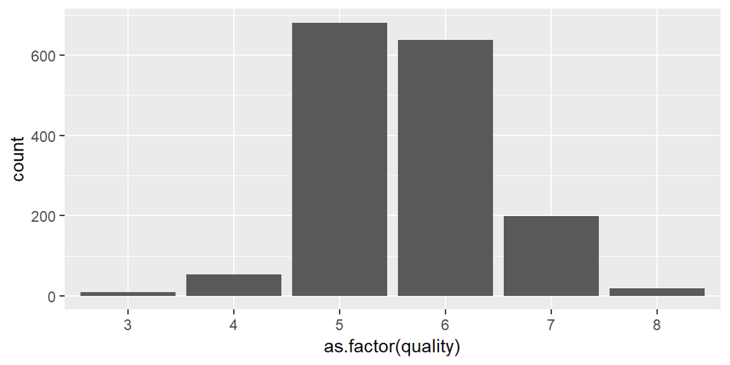

- From the above plot we can notice that the distribution of quality is **normal** and also **bimodal**.
- Most of the red wine quality at 5 & 6 grades no quality below 3 and there is no quality higher than 8.
- Now, Let’s plot simple historams of all other variables to see their distribution

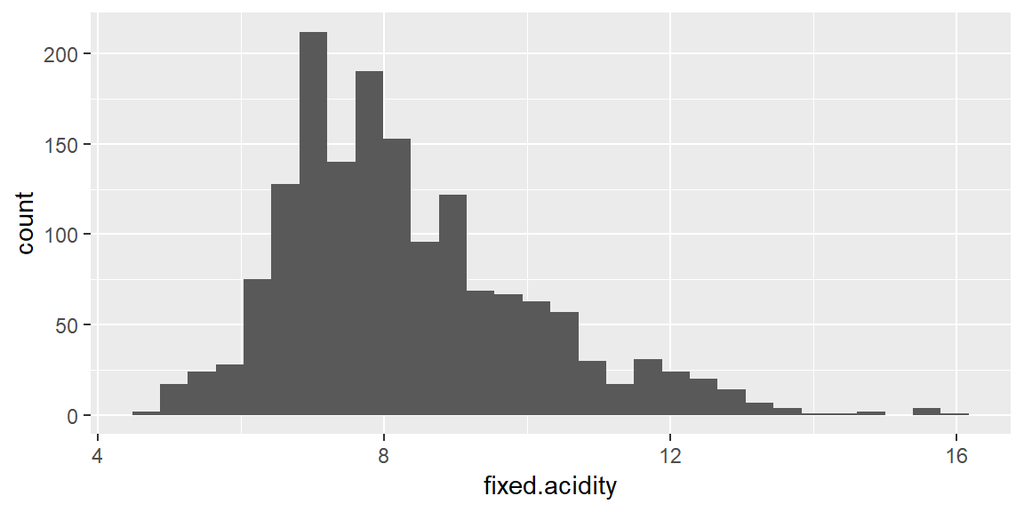

```
##    Min. 1st Qu.  Median    Mean 3rd Qu.    Max.
##    4.60    7.10    7.90    8.32    9.20   15.90
```

- Here the distribution of fixed acidity is to some extent **normally distributed**
- The majority of fixed acidity between 6-9.
- PPresence of outlier as high as 15.9

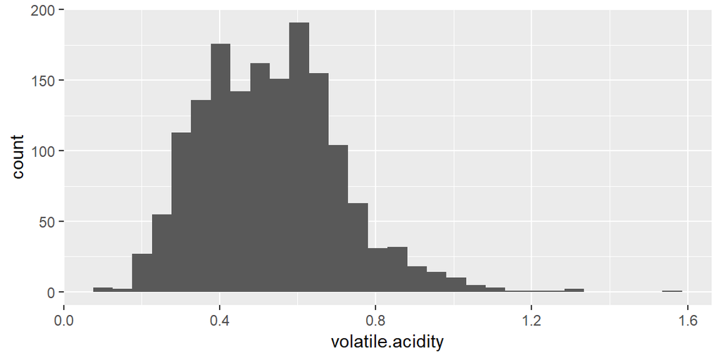

```
##    Min. 1st Qu.  Median    Mean 3rd Qu.    Max.
##  0.1200  0.3900  0.5200  0.5278  0.6400  1.5800
```

- The distribution of volatile acidity is considered **normal** with *two beaks*
- The mean and median values are close
- The majority between *0.2* and *0.8* and some outliers are present

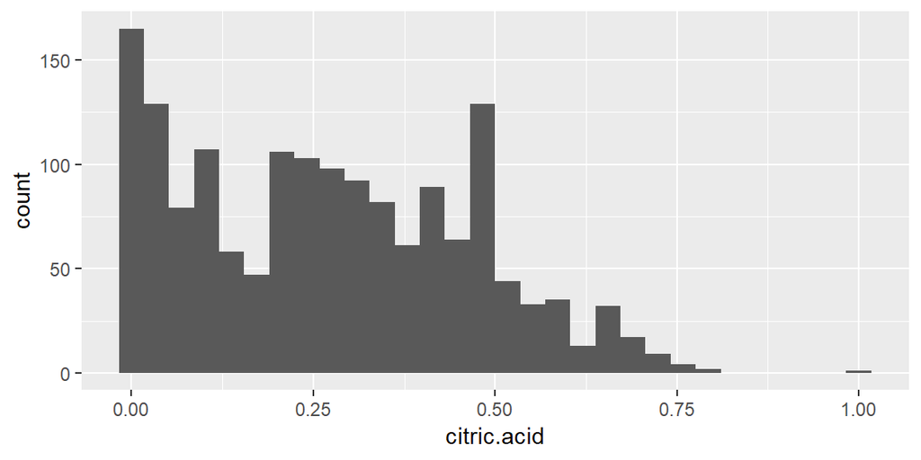

```
##    Min. 1st Qu.  Median    Mean 3rd Qu.    Max.
##   0.000   0.090   0.260   0.271   0.420   1.000
```

- There are some red wines with zero citric acid and there is still some outliers
- The distribution here is **positively skewed** with *two peaks*
- The mode of is *0*, which is consistent with the data info " found in small quantities, citric acid can add *freshness* and *flavor* to wines."

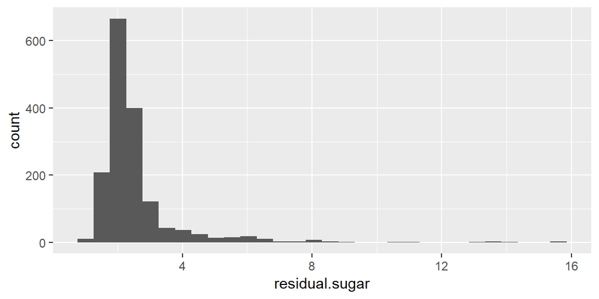

```
##    Min. 1st Qu.  Median    Mean 3rd Qu.    Max.
##   0.900   1.900   2.200   2.539   2.600  15.500
```

- The distribution is **Right skewed**
- The majority below *2.6* with some outliers which is considered **’Sweet*’** in this case.

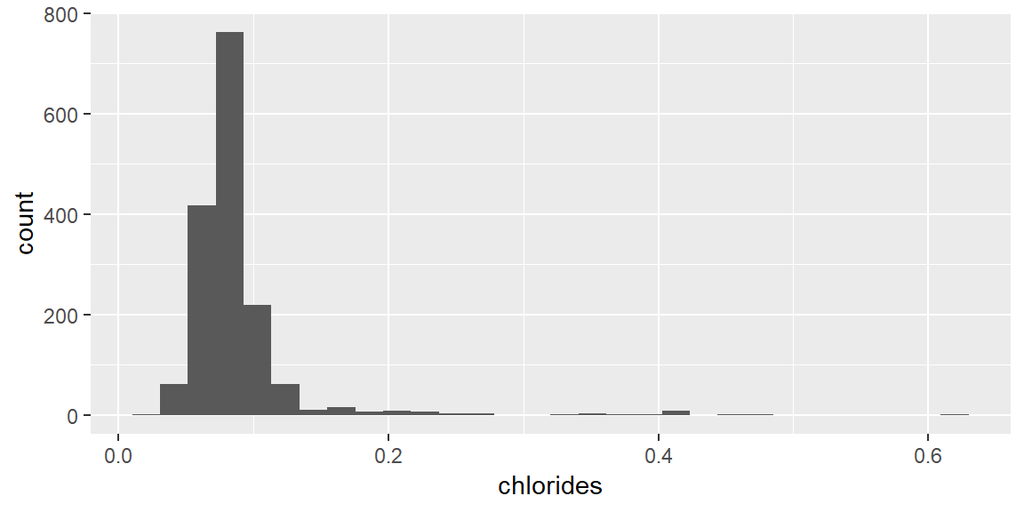

```
##    Min. 1st Qu.  Median    Mean 3rd Qu.    Max.
## 0.01200 0.07000 0.07900 0.08747 0.09000 0.61100
```

- Some outliers above **0.6** while the majority less than **0.1**
- All red wines in this dataset has a proportion of chlorides.

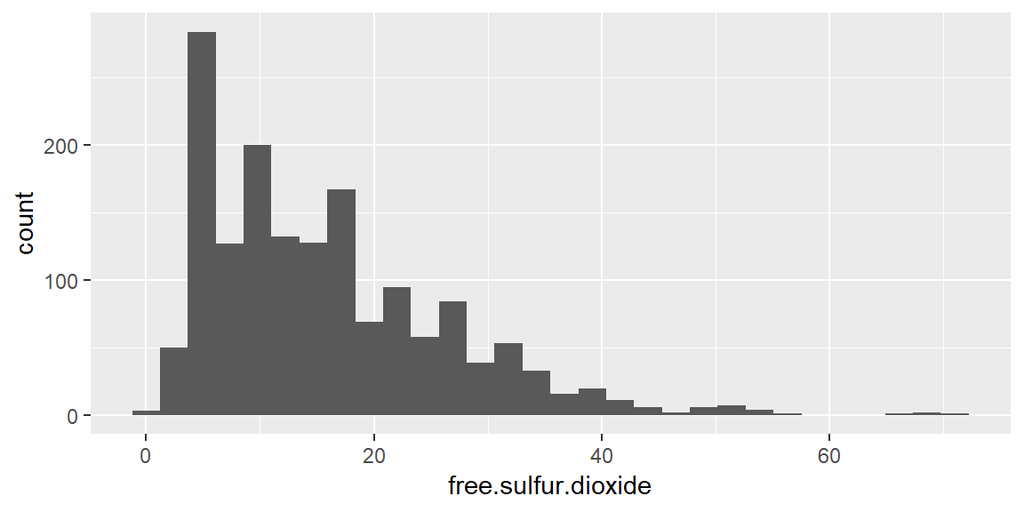

```
##    Min. 1st Qu.  Median    Mean 3rd Qu.    Max.
##    1.00    7.00   14.00   15.87   21.00   72.00
```

- The distribution here is **Right skewed** and with the most frequent value *Mode* around 5.
- Presence of vertical peaks indicates common concentration usd in different red wines.
- 75% of the datapoits have free SO2 concentration below *21* and there outliers as high as *72*

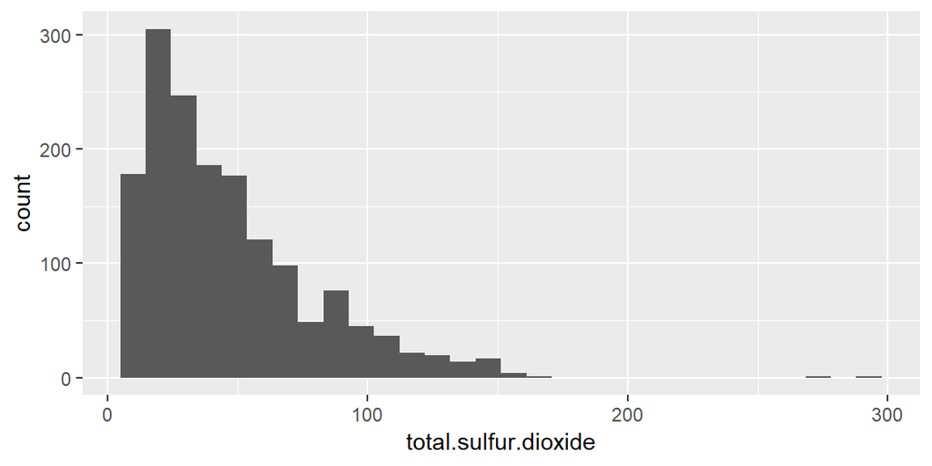

```
##    Min. 1st Qu.  Median    Mean 3rd Qu.    Max.
##    6.00   22.00   38.00   46.47   62.00  289.00
```

- The distribution again here is **Right Skewed**
- Too big values for the outliers while nearly *75%* of the values below *62*

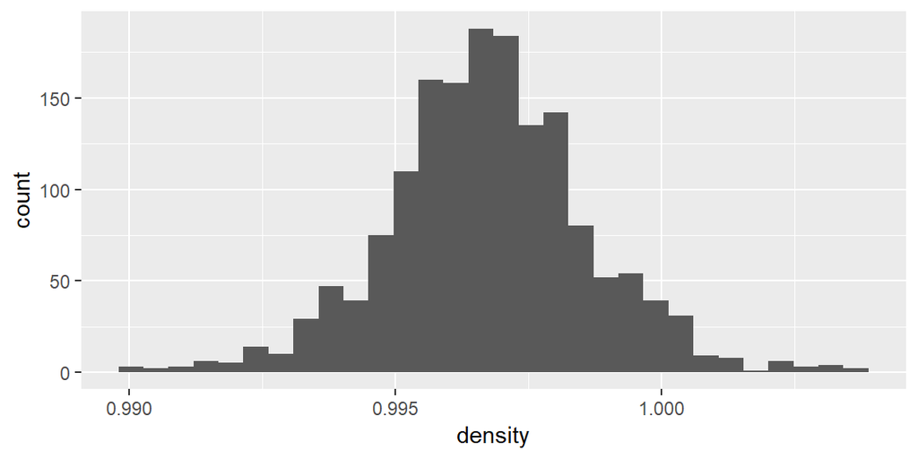

- Density distribution takes a **bell curve** style with the majority between 0.995 and 1

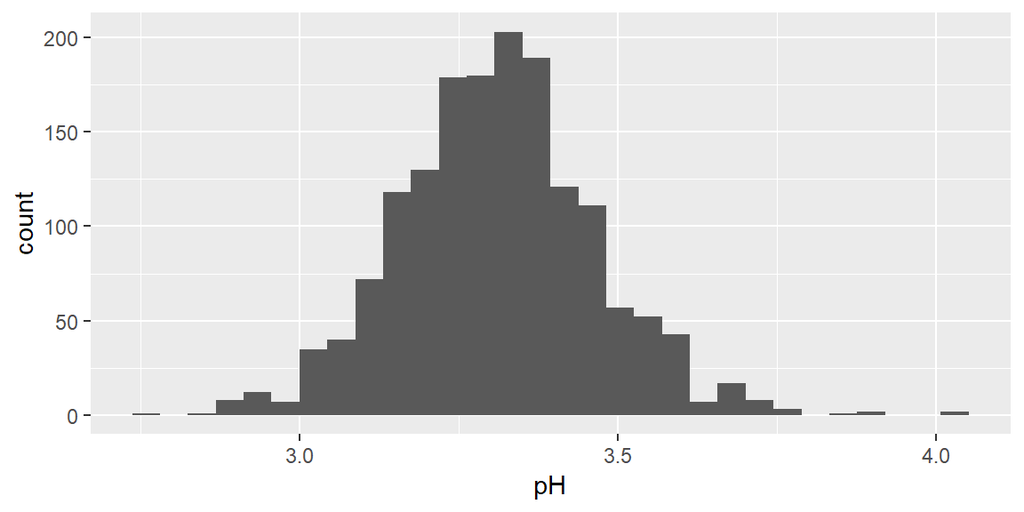

- Most PH values are between 3 & 3.5 with **Normal Distribution**

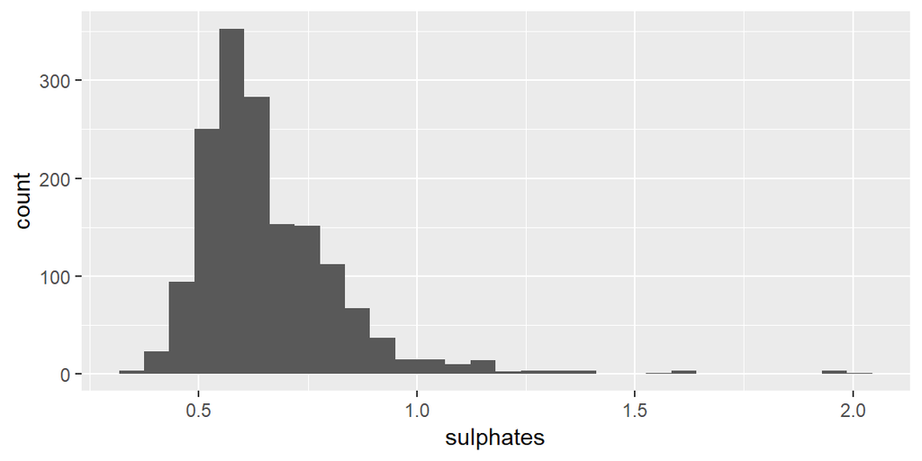

```
##    Min. 1st Qu.  Median    Mean 3rd Qu.    Max.
##  0.3300  0.5500  0.6200  0.6581  0.7300  2.0000
```

- The distribution of sulphates in our dataset is **Right skewed**
- The median and mean values are very close
- The majority of red wines in this dataset has been in the range of *0.5 to 1*
- Again presence of some outliers

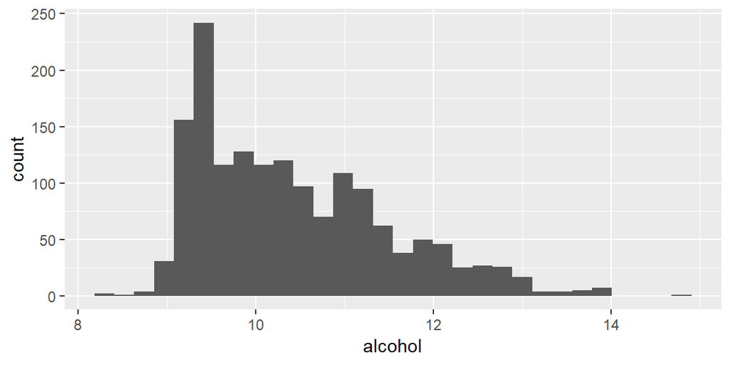

```
##    Min. 1st Qu.  Median    Mean 3rd Qu.    Max.
##    8.40    9.50   10.20   10.42   11.10   14.90
```

- Alcohol distibution is **Right skewed** with very close values for *mean* and *median*
- The avearge concentration of Alcohol here is around 10%
- Some outlier values above 14, *max = 14.90* while the minimum alcohol concentration at *8.4%*
- The most frequent value a little above *9*

```
##     bad average    good
##      63    1319     217
```

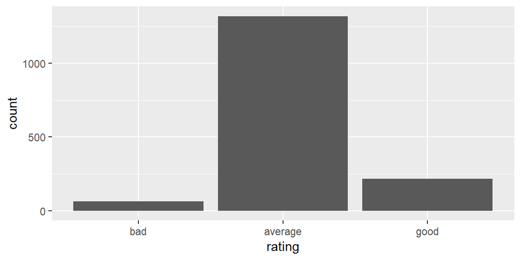

- From the above we conclude the majority of red wines rating is **average**

# Univariate Analysis

#### What is the structure of your dataset?

- There are 1599 wines in the dataset with 13 features. X referes for indexing.
- The variable of our intrest is **quality** and we generate **rating**
- 11 *chemical* variables : (fixed.acidity,volatile.acidity,citric.acid,residual.sugar,chlorides, free.sulfur.dioxide,total.sulfur.dioxide,density,pH,sulphates,alcohol)

#### What is/are the main feature(s) of interest in your dataset?

- The main feature here is **quality**.
- I would dive in the relationships between quality and other variables.

#### What other features in the dataset do you think will help support your investigation into your feature(s) of interest?

- From my point of view I think the following variables could share for wine quality:
1. The Alcohol
2. Volatile acidity as its high values leads to an unpleasant, vinegar taste
3. Citric acid as its the cause of freshness and flavors to wine
4. residual sugar as it affects the taste.

#### Did you create any new variables from existing variables in the dataset?

- Yes, I create a vriable **rating**.which is ordered factor with levels of **bad, average and good**

#### Of the features you investigated, were there any unusual distributions? Did you perform any operations on the data to tidy, adjust, or change the form of the data? If so, why did you do this?

- From the above plots I noticed some normal distribution and some Right skewed:
  1. **Normal distribution:** fixed.acidity, volatile.acidity, density and PH
  2. **Right Skewed :** citric.acid,cholrides,total.sulfur.dioxide, and sulphates.
- There is no tidy or adjust work as the data comes tidy, only I added the variable rating, to figure out the quality effect.

# Bivariate Plots Section

- First let’s plot the correlation between our intested features.

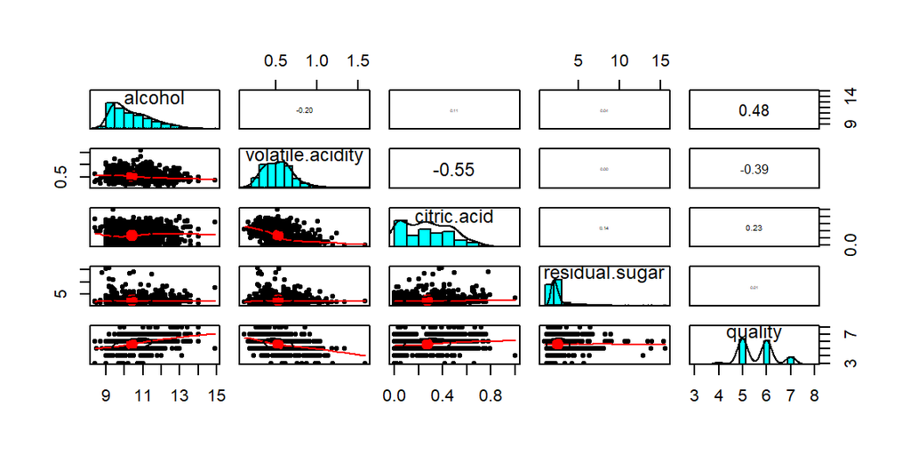

- Here we can notice that both alcohol and volatile.acidity are moderately correlated with quality which has almost no relationship with residual.suagar
- Almost strong negative correlationship between citric.acid and volatile.acidity
- Now let’s plot all the features as we could find something new

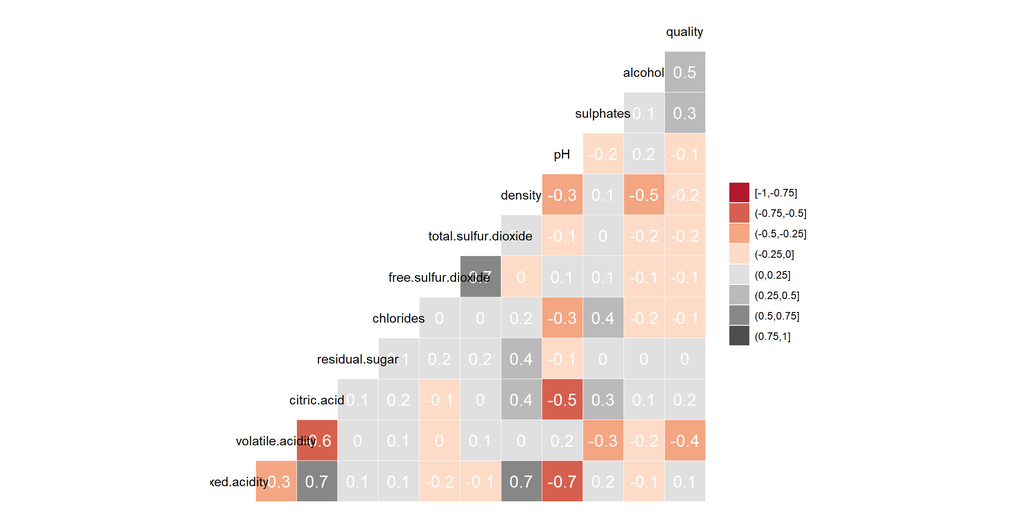

- From the above plot we can notice some strong realtionships between features like pH and acidity but my aim here is to focus on **qaulity**.

#### Correlation:

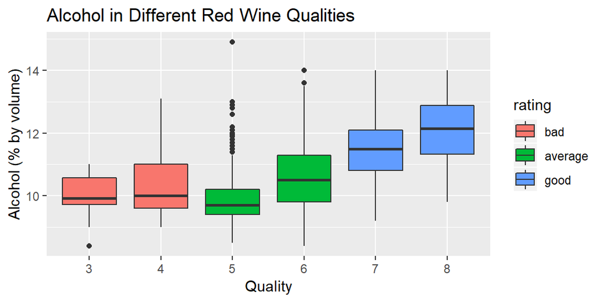

```
## # A tibble: 3 x 3
##   rating  alcohol_median     n
##   <fct>            <dbl> <int>
## 1 bad               10      63
## 2 average           10    1319
## 3 good              11.6   217
```

- From the above plot we can notice that **good quality** red wines has the **largest median** Alcohol compared to the other qualities, it’s obvious.

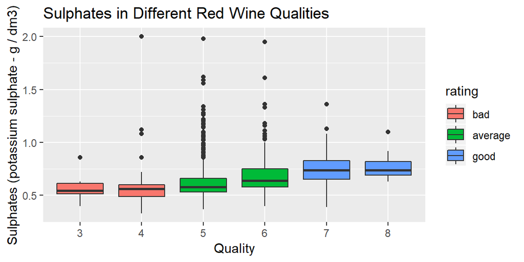

```
## # A tibble: 3 x 3
##   rating  sulphates_median     n
##   <fct>              <dbl> <int>
## 1 bad                 0.56    63
## 2 average             0.61  1319
## 3 good                0.74   217
```

- Here too we can notice that **good quality** red wines has the largest **median** sulphates compared to the other qualities.

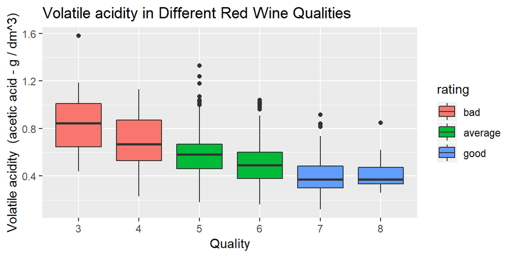

```
## # A tibble: 3 x 3
##   rating  volatile_acidity_median     n
##   <fct>                     <dbl> <int>
## 1 bad                        0.68    63
## 2 average                    0.54  1319
## 3 good                       0.37   217
```

- Here too as we expect that **good quality** red wines has the lowest **median** volatile.acidity compared to the other qualities.

Now let’s discover the other variables.

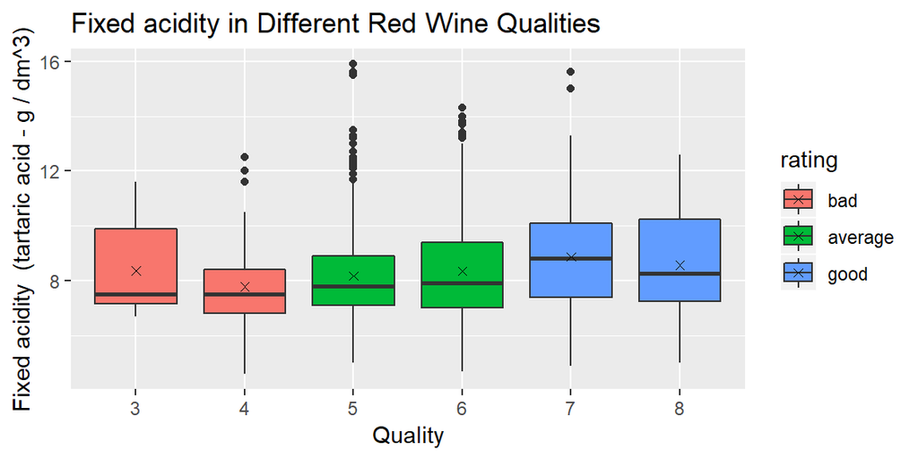

```
## # A tibble: 3 x 3
##   rating  fixed_acidity_median     n
##   <fct>                  <dbl> <int>
## 1 bad                      7.5    63
## 2 average                  7.8  1319
## 3 good                     8.7   217
```

- So, from the above it seems that **higher quality** wines has the **largest median fixed acidity**, while the median for both average and bad are so close, with a high range in the average quality,it was not obvious.

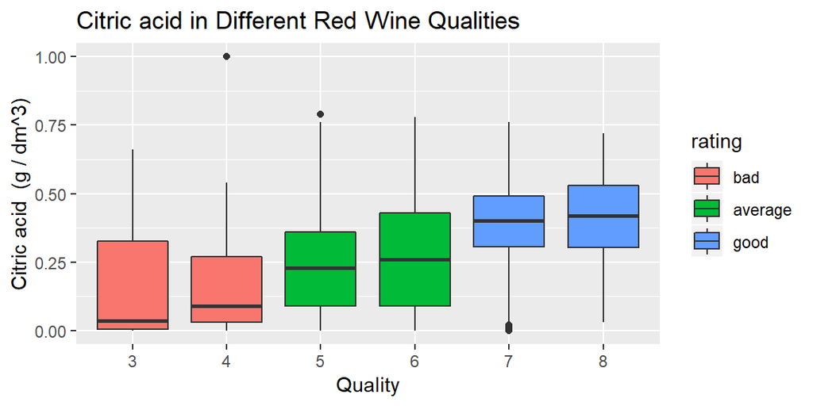

- Another noticable trend here although it was weak correlation between citric acid and quality, but from the above plot we can notice that **higher quality** red wines has the **largest median citric acid** while the lowest median citric acid in lowest quality.

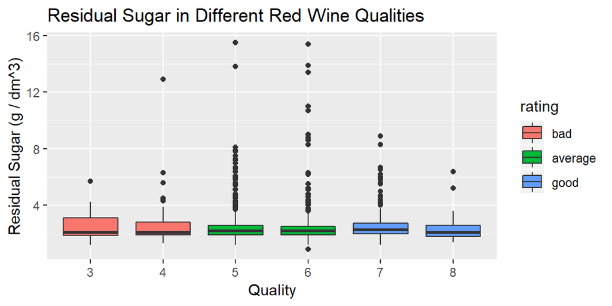

- median residual sugrar is almost the same, with presence of outliers , Although I assumed the importance of residual sugar effect on quality but from the above plot I get back.

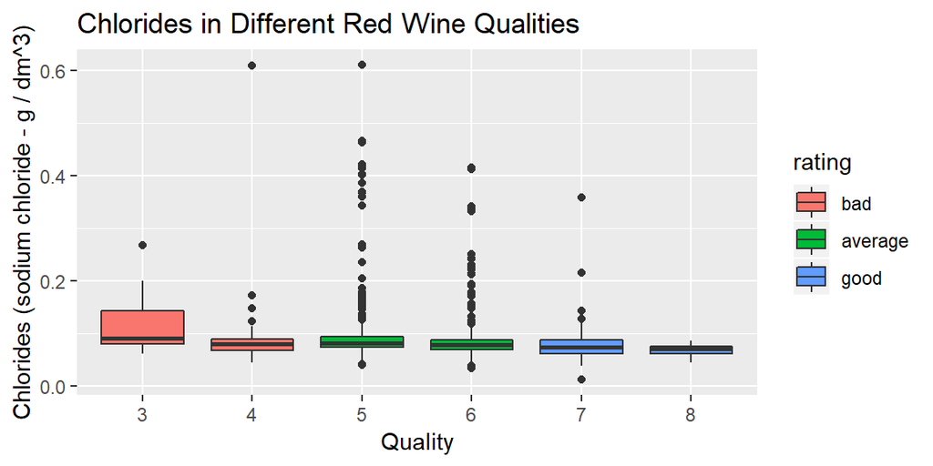

- Almost the same median of chlorides for all qualities, except the smalest range for the highest quality, also outlier present here.

```
## # A tibble: 3 x 3
##   rating  chlorides_median     n
##   <fct>              <dbl> <int>
## 1 bad                0.08     63
## 2 average            0.08   1319
## 3 good               0.073   217
```

- Here higher quality wines have the lowest chlorides.

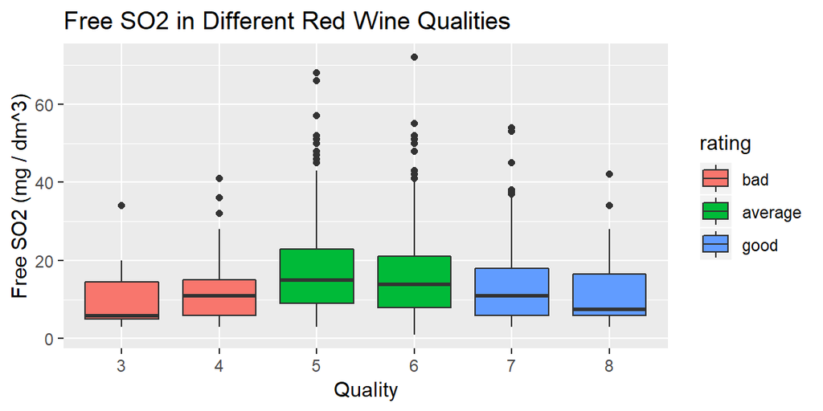

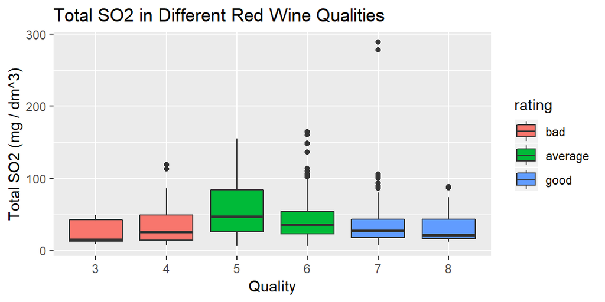

- From the above two plots for Free SO2 and total SO2, it seems that the largest median is present in the avearage rating group.

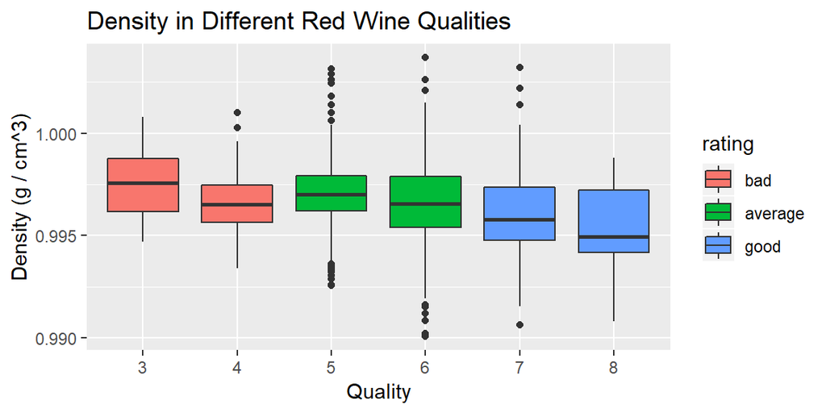

- Another notice here although it was weak negative correlation between density and quality, but from the above plot we can notice a clear trend that **higher quality** red wines has the **lowest median density** and the highest density in the lowest quality red wines.

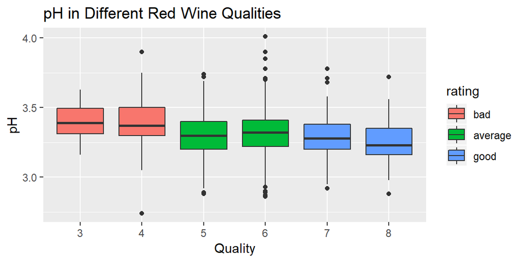

- From the above we can notice a trend between pH and quality,as in the highest quality of red wines pH medain values are the lowest.

Now let’s figure out the realtion between different variables

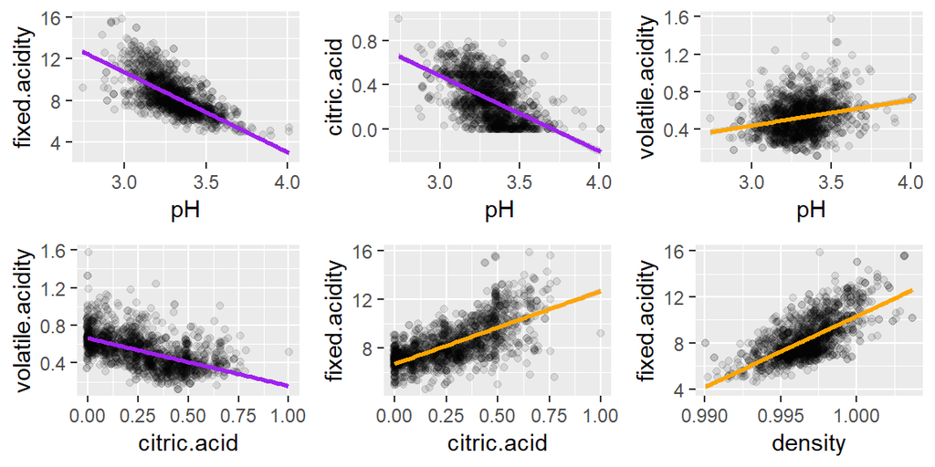

- It worth to figure how these variables correaltes to each other:
1. **Postiviely**: -pH with volatile.acidity -fixed acidity with both density and citric.acid.
2. **Negatively**: -pH with both citric.acid and fixed.acidity -citric.acid with volatile acidity.

# Bivariate Analysis

#### Did you observe any interesting relationships between the other features (not the main feature(s) of interest)?

1. **Positive Correlations** : - Alcohol with quality - pH with volatile.acidity - fixed acidity with both density and citric.acid.
2. **Negative Correlations**: - pH with both citric.acid and fixed.acidity - citric.acid with volatile acidity.

#### What was the strongest relationship you found?

# Multivariate Plots Section

From the previous bivariate analysis we conclude that Alcohol has the strongest correlation wih quality.

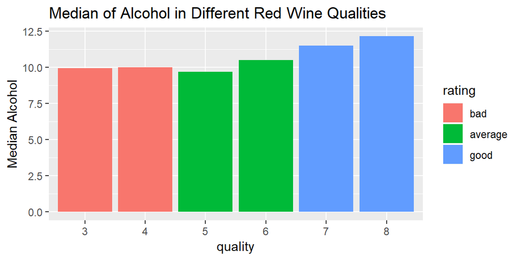

```
## # A tibble: 6 x 5
##   rating  quality mean_alc median_alc     n
##   <fct>   <ord>      <dbl>      <dbl> <int>
## 1 bad     3           9.96       9.93    10
## 2 bad     4          10.3       10       53
## 3 average 5           9.90       9.7    681
## 4 average 6          10.6       10.5    638
## 5 good    7          11.5       11.5    199
## 6 good    8          12.1       12.2     18
```

Now, Let’s divide in more about alcohol with other variables starting with fixed acidity.

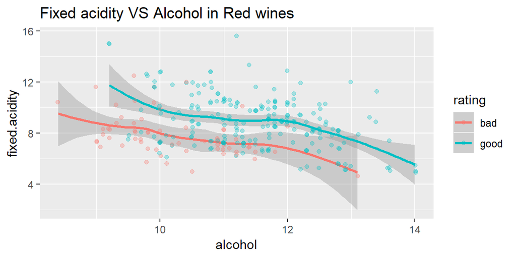

- The higher quality of red wines tend to have **higher fixed acidity**.

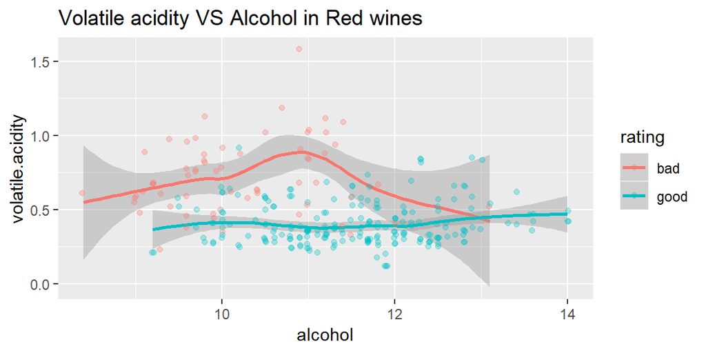

- On the other hand tend to have a lower volatile acidity , so let’s figure how they act in the ratio of fixed:volatile acidity

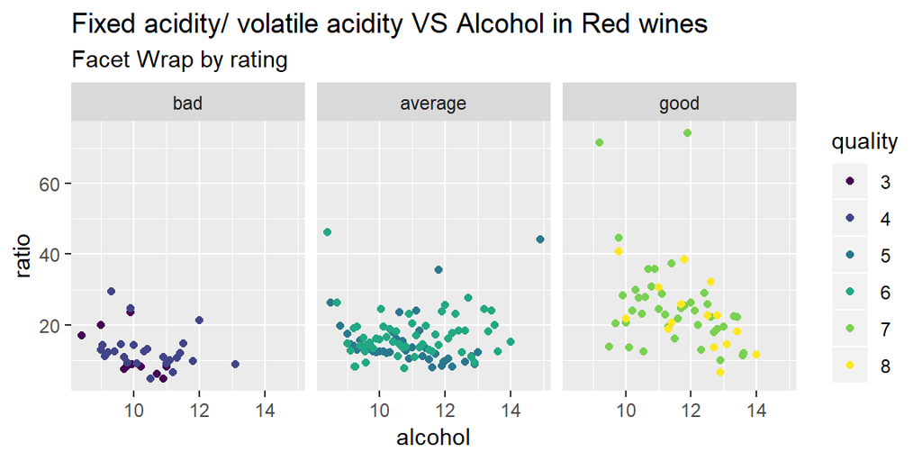

- Let’s focus more on difference between bad and good qualities.

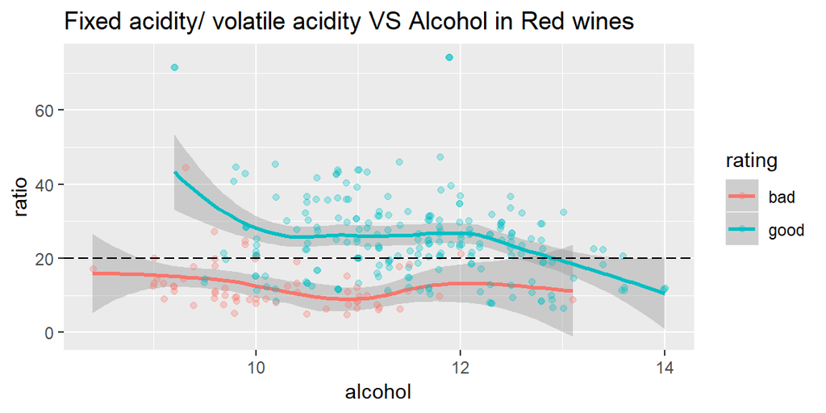

- That is intersting for me, the higher qulaity red wines tend to have higher fixed acidity to volatile acidity ratio above *20*, also the majority of average & bad red wines at different concentration of alcohol tends to have fixed:volatile ratio at below that line.